# TreeClassification-HighRes-IndividualUser

Aitor Apaolaza

12/01/2016

*Copyright (c) 2015 The University of Manchester, UK.*

*Licenced under LGPL version 2.1. See LICENCE for details.*

*The IDInteraction Attention Classification was developed in the IDInteraction project, funded by the Engineering and Physical Sciences Research Council, UK through grant agreement number EP/M017133/1.*

*Author: Aitor Apaolaza*

## Initialisation and loading data

```
## [1] "All listed packages are already installed"
```

# Setup for the classification algorithm.

**Folder**: /home/aitor/Dropbox/UoM/IDInteractionCode/Rnotebooks

**Experiment**: dual_screen_free_experiment

**Source Videos**: high_quality

**Tracking system**: front_full_face

**Using the following list of participants**: P12.

**Using the following timelimit threshold to separate training and testing data**: 1.

Data for these participants will be read from the CSV files contained in the following folders:

/home/aitor/Dropbox/UoM/IDInteractionCode/Rnotebooks/resources/dual_screen_free_experiment/high_quality/attention/

/home/aitor/Dropbox/UoM/IDInteractionCode/Rnotebooks/resources/dual_screen_free_experiment/high_quality/front_full_face/

Loading data for participant P12

```
## [1] "Processing participant: P12"
## [1] "START of combineCSVsToDF()"
## [1] "END of combineCSVsToDF()"
## [1] "START of createFeatureDF()"
## [1] "END of createFeatureDF()"
```

## Training the tree classifier

Using the **rpart** library for the following formula:

**attentionName ~ boxHeight + boxRotation + boxArea + boxWidth + widthHeightRatio + boxYcoordRel**

Resulting model:

```
## n= 2526
##
## node), split, n, loss, yval, (yprob)
##       * denotes terminal node
##
##  1) root 2526 927 tv (0.36698337 0.63301663)
##    2) boxHeight< 42.56535 986 177 ipad (0.82048682 0.17951318)
##      4) boxYcoordRel>=0.3239422 688  54 ipad (0.92151163 0.07848837)
##        8) boxRotation< 2.200855 628  28 ipad (0.95541401 0.04458599) *
##        9) boxRotation>=2.200855 60  26 ipad (0.56666667 0.43333333)
##         18) boxYcoordRel>=0.3948542 27   0 ipad (1.00000000 0.00000000) *
##         19) boxYcoordRel< 0.3948542 33   7 tv (0.21212121 0.78787879) *
##      5) boxYcoordRel< 0.3239422 298 123 ipad (0.58724832 0.41275168)
##       10) boxRotation< 4.67246 267  96 ipad (0.64044944 0.35955056)
##         20) boxHeight< 38.50085 96  15 ipad (0.84375000 0.15625000) *
##         21) boxHeight>=38.50085 171  81 ipad (0.52631579 0.47368421)
##           42) boxRotation>=0.177032 65  12 ipad (0.81538462 0.18461538) *
##           43) boxRotation< 0.177032 106  37 tv (0.34905660 0.65094340) *
##       11) boxRotation>=4.67246 31   4 tv (0.12903226 0.87096774) *
##    3) boxHeight>=42.56535 1540 118 tv (0.07662338 0.92337662)
##      6) boxRotation>=8.10246 90   8 ipad (0.91111111 0.08888889) *
##      7) boxRotation< 8.10246 1450  36 tv (0.02482759 0.97517241) *
```

From the R manual for the Complexity Parameter Table for an Rpart Fit: *The cptable in the fit contains the mean and standard deviation of the errors in the cross-validated prediction against each of the geometric means.*

Matrix of information on the optimal prunings based on a complexity parameter.

```
##
## Classification tree:
## rpart(formula = formula, data = trainsetclass, method = "class")
##
## Variables actually used in tree construction:
## [1] boxHeight    boxRotation  boxYcoordRel
##
## Root node error: 927/2526 = 0.36698
##
## n= 2526
##
##         CP nsplit rel error  xerror     xstd
## 1 0.681769      0   1.00000 1.00000 0.026132
## 2 0.079827      1   0.31823 0.32578 0.017590
## 3 0.012406      2   0.23840 0.25027 0.015658
## 4 0.010248      6   0.17907 0.21791 0.014706
## 5 0.010000      8   0.15858 0.20388 0.014265
```

Visualisation of the Complexity Parameter Table. *A good choice of cp for pruning is often the leftmost value for which the mean lies below the horizontal line.*

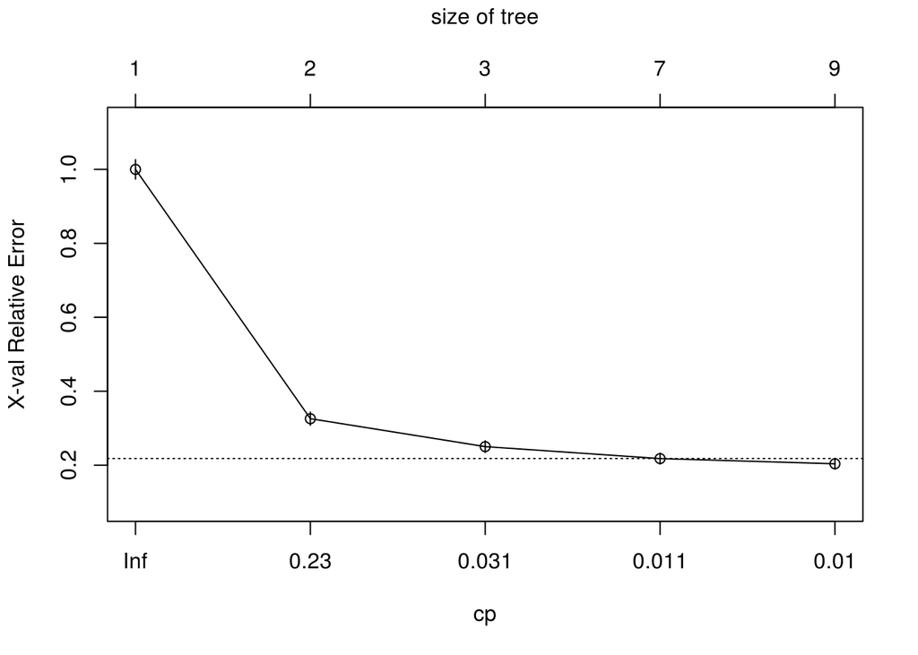

## Tree

### Summary of the tree

```
##
## Model formula:
## attentionName ~ boxHeight + boxRotation + boxArea + boxWidth +
##     widthHeightRatio + boxYcoordRel
##
## Fitted party:
## [1] root
## |   [2] boxHeight < 42.56535
## |   |   [3] boxYcoordRel >= 0.32394
## |   |   |   [4] boxRotation < 2.20085: ipad (n = 628, err = 4.5%)
## |   |   |   [5] boxRotation >= 2.20085
## |   |   |   |   [6] boxYcoordRel >= 0.39485: ipad (n = 27, err = 0.0%)
## |   |   |   |   [7] boxYcoordRel < 0.39485: tv (n = 33, err = 21.2%)
## |   |   [8] boxYcoordRel < 0.32394
## |   |   |   [9] boxRotation < 4.67246
## |   |   |   |   [10] boxHeight < 38.50085: ipad (n = 96, err = 15.6%)
## |   |   |   |   [11] boxHeight >= 38.50085
## |   |   |   |   |   [12] boxRotation >= 0.17703: ipad (n = 65, err = 18.5%)
## |   |   |   |   |   [13] boxRotation < 0.17703: tv (n = 106, err = 34.9%)
## |   |   |   [14] boxRotation >= 4.67246: tv (n = 31, err = 12.9%)
## |   [15] boxHeight >= 42.56535
## |   |   [16] boxRotation >= 8.10246: ipad (n = 90, err = 8.9%)
## |   |   [17] boxRotation < 8.10246: tv (n = 1450, err = 2.5%)
##
## Number of inner nodes:    8
## Number of terminal nodes: 9
```

### Visualisation of the tree

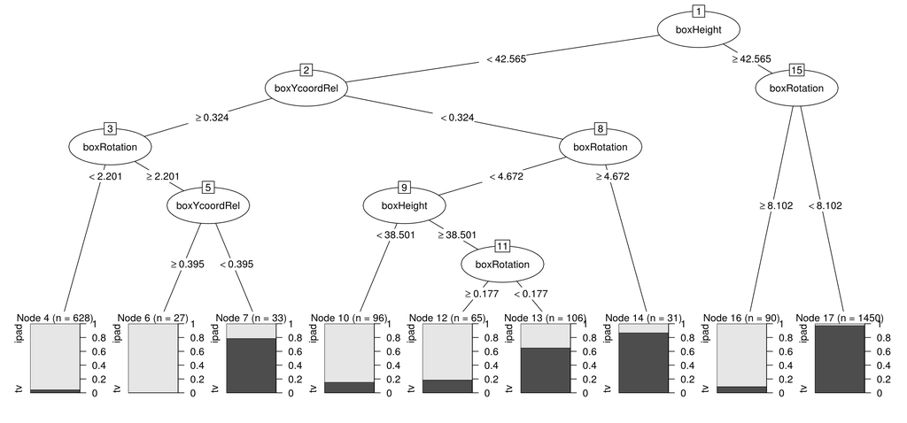

Tree classifier plot

## Error metrics analysis

Confusion matrix from the application of the tree predictor to the testing set of data.

```
##       predclass
##         ipad    tv
##   ipad 10706  1213
##   tv    6845 24016
```

### Error metrics based on prediction of attention to the iPad.

True negatives: 24016

False negatives: 6845

True positives: 10706

False positives: 1213

**Error-rate**: the proportion of the incorrectly classified examples -> (fp+fn)/(tp+tn+fp+tn)

**18.8359046**

**Accuracy**: the proportion of the correctly classified examples -> (tp+tn)/(tp+tn+fp+tn)

**81.1640954**

As the number of instances of the response variable is not balanced (there are many more instances with false than true) the accuracy is not a good indicator. Other cost sensitive measures are reported here. -> cost sensitive measures

**Precision**: positive predicted value (PPV) -> tp/(tp+fp), a measure of exactness

**89.8229717**

**Recall/Sensitivity**: true positive recognition rate -> tp/(tp+fn), a measure of completeness

**60.9993733**

**Specificity**: true negative recognition rate -> tn/(tn+fp)

**95.1920409**

**F measure**: the balance between precision and recall -> 2*tp/(2*tp+fp+fn)

**72.6569393**

### Error metrics based on prediction of attention to the TV.

True negatives: 10706

False negatives: 1213

True positives: 24016

False positives: 6845

**Error-rate**: the proportion of the incorrectly classified examples -> (fp+fn)/(tp+tn+fp+tn)

**18.8359046**

**Accuracy**: the proportion of the correctly classified examples -> (tp+tn)/(tp+tn+fp+tn)

**81.1640954**

As the number of instances of the response variable is not balanced (there are many more instances with false than true) the accuracy is not a good indicator. Other cost sensitive measures are reported here. -> cost sensitive measures

**Precision**: positive predicted value (PPV) -> tp/(tp+fp), a measure of exactness

**77.8199021**

**Recall/Sensitivity**: true positive recognition rate -> tp/(tp+fn), a measure of completeness

**95.1920409**

**Specificity**: true negative recognition rate -> tn/(tn+fp)

**60.9993733**

**F measure**: the balance between precision and recall -> 2*tp/(2*tp+fp+fn)

**85.6338028**